# IODS course project

Alisa Elizarova

# About the project

I am very excited about this course. I think I will learn a lot of interesting and very useful things. I study statistics, so I want this course be a bit more practical that my other studies.

Johanna Tuhkanen recommended me this course. Also, I got a letter from Kimmo Vehkalahti advertising this course.

#### A link to my GitHub repository:

[Here!](https://github.com/elizarovaalisa/IODS-project)

# Exercise 2

### The data reading and exploring

```r
students14 <- read.table("http://s3.amazonaws.com/assets.datacamp.com/production/course_2218/datasets/learning2014.txt", sep=",", header=TRUE)
head(students14)
```

```
##   gender age attitude     deep  stra     surf points
## 1      F  53      3.7 3.583333 3.375 2.583333     25
## 2      M  55      3.1 2.916667 2.750 3.166667     12
## 3      F  49      2.5 3.500000 3.625 2.250000     24
## 4      M  53      3.5 3.500000 3.125 2.250000     10
## 5      M  49      3.7 3.666667 3.625 2.833333     22
## 6      F  38      3.8 4.750000 3.625 2.416667     21
```

```r
str(students14)
```

```
## 'data.frame':    166 obs. of  7 variables:
##  $ gender  : Factor w/ 2 levels "F","M": 1 2 1 2 2 1 2 1 2 1 ...
##  $ age     : int  53 55 49 53 49 38 50 37 37 42 ...
##  $ attitude: num  3.7 3.1 2.5 3.5 3.7 3.8 3.5 2.9 3.8 2.1 ...
##  $ deep    : num  3.58 2.92 3.5 3.5 3.67 ...
##  $ stra    : num  3.38 2.75 3.62 3.12 3.62 ...
##  $ surf    : num  2.58 3.17 2.25 2.25 2.83 ...
##  $ points  : int  25 12 24 10 22 21 21 31 24 26 ...
```

```r
dim(students14)
```

```
## [1] 166   7
```

The data is collected from the survey on teaching and learning. In this data, we have 166 students’ answers. In each observation, we have a responder’s age and gender. Also, we have 4 variables that measure student’s deep, surface and strategic approach to learning and his/her attitude toward statistics. The last variable “points” tells us his/her exam score.

```r
library(ggplot2)
library(GGally)

summary(students14)
```

```
##  gender       age           attitude          deep            stra
##  F:110   Min.   :17.00   Min.   :1.400   Min.   :1.583   Min.   :1.250
##  M: 56   1st Qu.:21.00   1st Qu.:2.600   1st Qu.:3.333   1st Qu.:2.625
##          Median :22.00   Median :3.200   Median :3.667   Median :3.188
##          Mean   :25.51   Mean   :3.143   Mean   :3.680   Mean   :3.121
##          3rd Qu.:27.00   3rd Qu.:3.700   3rd Qu.:4.083   3rd Qu.:3.625
##          Max.   :55.00   Max.   :5.000   Max.   :4.917   Max.   :5.000
##       surf           points
##  Min.   :1.583   Min.   : 7.00
##  1st Qu.:2.417   1st Qu.:19.00
##  Median :2.833   Median :23.00
##  Mean   :2.787   Mean   :22.72
##  3rd Qu.:3.167   3rd Qu.:27.75
##  Max.   :4.333   Max.   :33.00
```

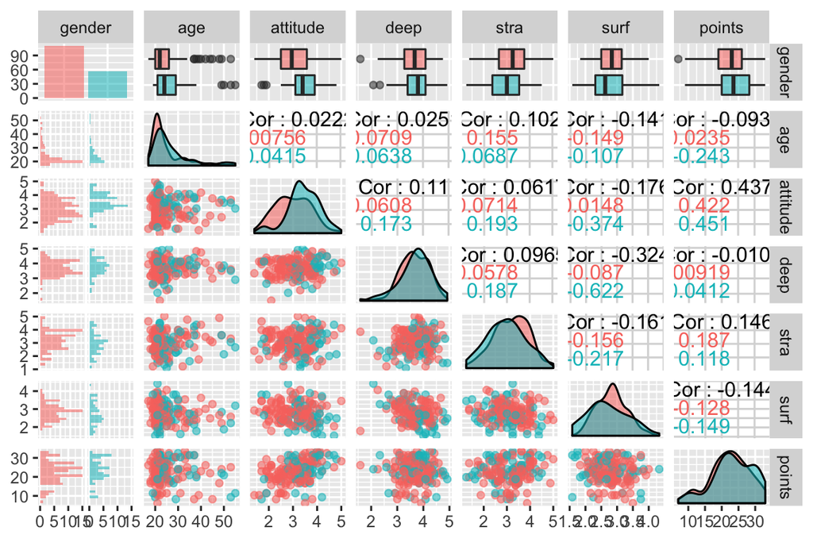

```r
ggpairs(students14, mapping = aes(col = gender, alpha = 0.3), lower = list(combo = wrap("facethist", bins = 20)))
```

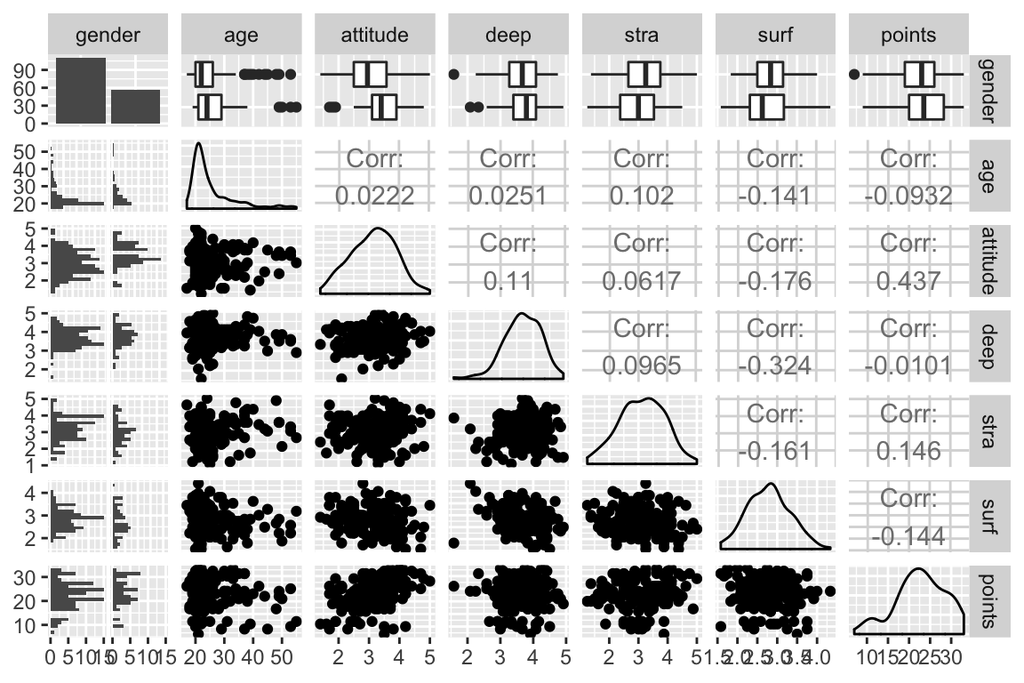

```r
ggpairs(students14, mapping = aes(), lower = list(combo = wrap("facethist", bins = 20)))
```

Let us first describe the distributions of the variables. Then we will take a look at their connection to each other, especially to the “points” variable.

With this data, it is very hard to notice any corrections between this variable. Fortunately, the plot helps us. The strongest correlation happens between “attitude” and “points” variables. Additionally, there is a negative correlation (-0.3, not very strong) between deep and surface approaches.

Structural and surface approaches correlate with points, as well. I think that those variables and “attitude” should be chosen as explanatory variables for a regression model where exam points are the response variable.